# Project 1: Hurricanes Data

2. Which months are the top three most active (where most of the hurricanes tend to occur)?

```r
#Months with corresponding hurricane counts for each
num_hurricane_by_month <- dat %>% group_by(MONTH) %>% summarize(count = n())

#Months with corresponding hurricane counts for each, sorted from most hurricanes to least
active_months_sorted <- num_hurricane_by_month %>% arrange(desc(count))

#Top 3 months with the most hurricanes
top_3_active <- head(active_months_sorted, 3)
top_3_active
```

```
## # A tibble: 3 x 2
##   MONTH count
##   <dbl> <int>
## 1     9 13864
## 2     8  8530
## 3    10  6045
```

For this research question, I began with the original dataset, `dat`, and grouped the data by month since we are interested in seeing the number of hurricanes by month. I then summarized the data using summarize() and count(), to obtain the corresponding number of hurricanes for each month, and labeled it `num_hurricane_by_month`. Next, I sorted the table of hurricane counts by month from largest number of hurricanes to fewest, and labeled it `active_months_sorted`. Lastly, I used the head() function to obtain the top three rows of the table and named it `top_3_active`. This tibble, `top_3_active`, shows the three months that had the most hurricanes, in decreasing order.

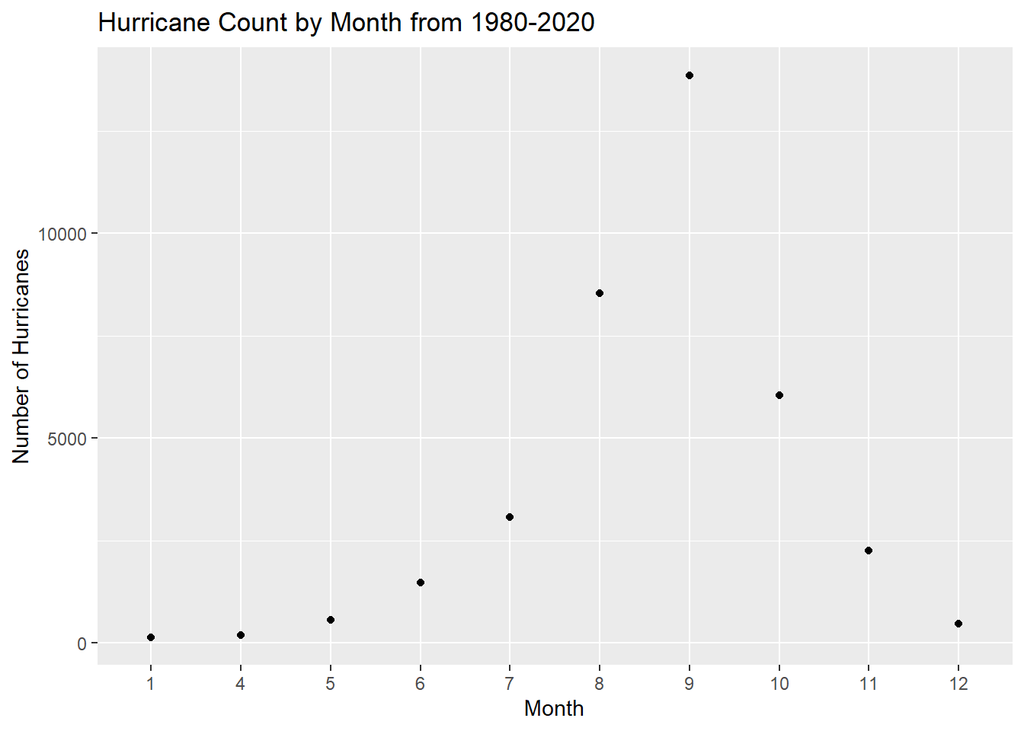

```r
ggplot(num_hurricane_by_month, aes(x = factor(MONTH), y = count)) +
  geom_point() +
  labs(title = "Hurricane Count by Month from 1980-2020", x = "Month",
                    y = "Number of Hurricanes")
```

As shown in the tibble `top_3_active` and the above graphic visual, which maps the number of hurricanes by month, the top three most active months are months 9, 8, and 10. I made this visualization so I would be able to more easily visualize the distribution of hurricane counts across the months that we had available data for. This graph highlights which months the hurricane count spikes occurred.

In conclusion, the top three most active months are September, August, and October, in that order.

3. During the analyzed period (1980-2020), are there any hurricanes that made U.S.landfall before June and after November?

```r
#Table of all hurricanes that made landfall before June and after November
landfall_hurricanes <- dat %>% filter(DIST2LAND == 0) %>%
  filter(MONTH < 6 | MONTH > 11)

#List of countries where hurricanes made landfall before June and after November,found using longitude and latitude values
landfall_countries <- map.where(database = "world", landfall_hurricanes$LON,
                 landfall_hurricanes$LAT)

#Shortened version of entire landfall_countries list
head(landfall_countries, 50)
```

```
##  [1] NA                   "Cuba"               NA
##  [4] "Cuba"               NA                   "Cuba"
##  [7] "Dominican Republic" "Dominican Republic" "Dominican Republic"
## [10] "Dominican Republic" "Dominican Republic" "Puerto Rico"
## [13] "Puerto Rico"        "Dominican Republic" "Dominican Republic"
## [16] "Dominican Republic" "Dominican Republic" "Haiti"
## [19] "Mexico"             "Belize"             "Belize"
## [22] "Belize"             "Mexico"             "Mexico"
## [25] "USA"                "USA"                "USA"
## [28] "USA"                "USA"                "USA"
## [31] "USA"                "USA"                "USA"
## [34] "USA"                "USA"                "USA"
## [37] "USA"                "USA"                "USA"
## [40] "USA"                "USA"                "USA"
## [43] "USA"                "USA"                NA
## [46] "Mexico"             "Mexico"             "Mexico"
## [49] "Mexico"             "Mexico"
```

To answer the last research question, I began by making a new dataset (from the original `dat`) called `landfall_hurricanes`, which only included the hurricanes that made landfall before June and after November. To do this, I used the filter() function and specified for DIST2LAND == 0 (hurricanes that made landfall) and MONTH < 6 or MONTH > 11 (landfall before June and after November). Next, I used the `maps` package in R to get a list of countries where these hurricanes made landfall by using the longitude and latitude provided. I did this by using the function map.where() and inputting longitude values (`landfall_hurricanes$LON`) and latitude values (`landfal_hurricanes$LAT`). I labeled this list of countries `landfall_countries` and used the function head() to get a shortened version of the list. By studying `landfall_countries`, we can see that “USA” is included in the list, which means that there were hurricanes that made U.S.landfall before June and after November.

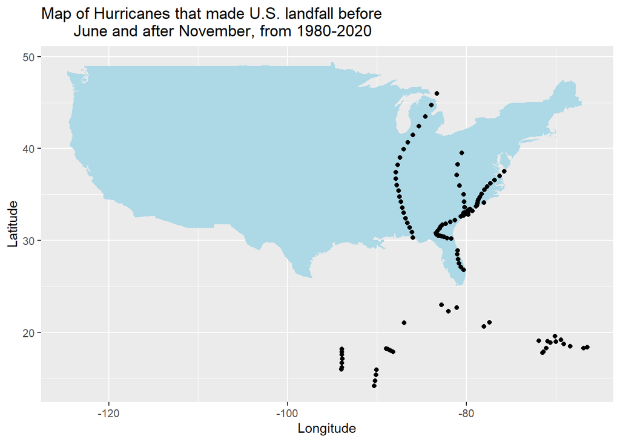

```r
#Data frame of the points that make up the outline of the U.S.
usa <- map_data("usa")

#Map of U.S. with longitude and latitude points of U.S. landfall (before June and after November) plotted
ggplot() +
  geom_polygon(data = usa, aes(x = long, y = lat, group = group), fill = "light blue") +
  geom_point(aes(x = landfall_hurricanes$LON, y = landfall_hurricanes$LAT)) +
  labs(title = "Map of Hurricanes that made U.S. landfall before
       June and after November, from 1980-2020", x = "Longitude",
  y = "Latitude")
```

In conclusion, during the analyzed period between 1980 and 2020, there were hurricanes that made U.S. landfall before June and after November.